# 学习笔记

### 位置调整与条形图

位置调整（Position adjustments）是针对同一图层内元素的位置进行微调的方法。它包括五种设置，分别是stack、dodge、fill、identity、jitter。

我们用条形图来展示其用法，仍使用mpg数据集，其中用到的变量是class，即生产汽车的类型，以及year生产年份。下面的条形图是将各类型的汽车数量进行汇集，并以年份作为分组变量。我们首先载入扩展包，然后用频数表对数据进行大致的了解，最后绘制了四种条形图。

```r
library(ggplot2)
with(mpg,table(class,year))
```

```
##             year
## class        1999 2008
##   2seater       2    3
##   compact      25   22
##   midsize      20   21
##   minivan       6    5
##   pickup       16   17
##   subcompact   19   16
##   suv          29   33
```

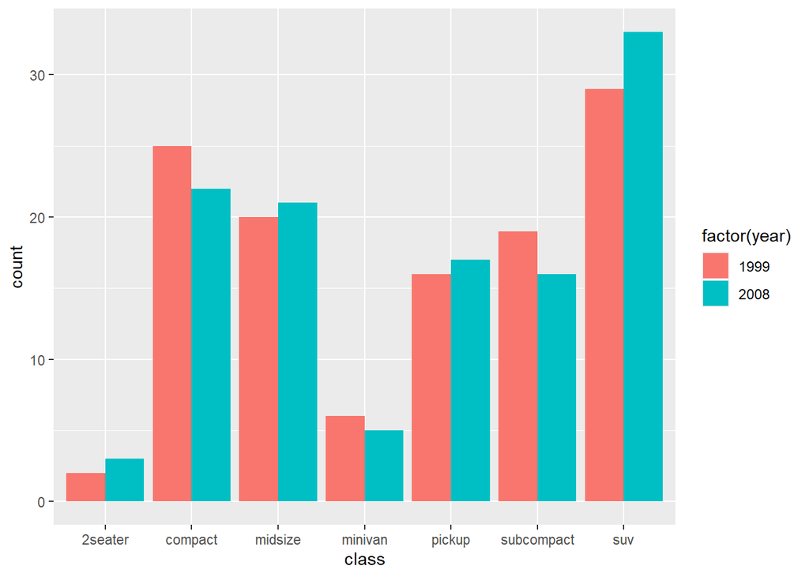

```r
p <- ggplot(data=mpg,aes(x=class,fill=factor(year)))
p + geom_bar(position='dodge')
```

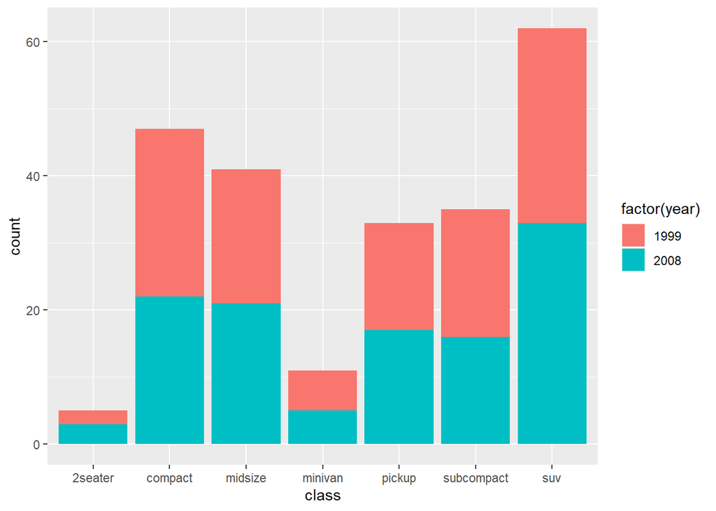

```r
p + geom_bar(position='stack')
```

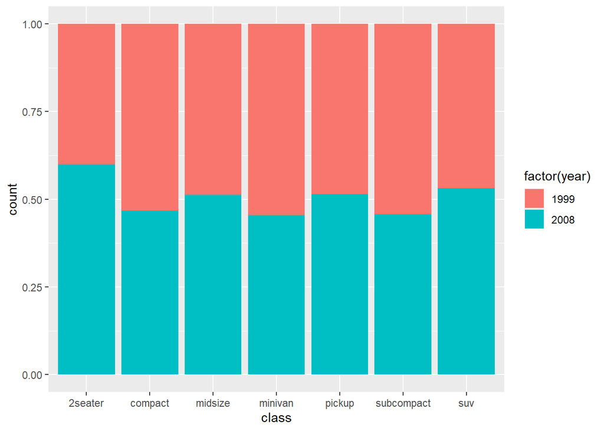

```r
p + geom_bar(position='fill')
```

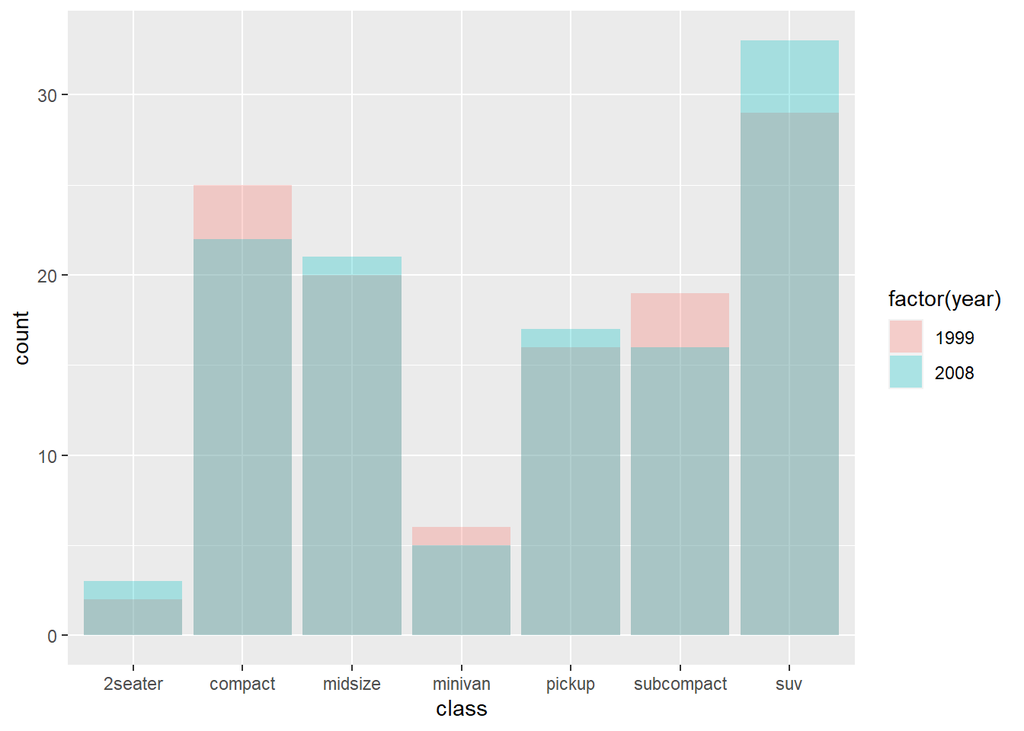

```r
p + geom_bar(position='identity',alpha=0.3)
```

可以看到dodge方式是将不同年份的数据并列放置；stack方式是将不同年份数据推叠放置，这也是geom_bar的默认处理方式；fill方式和stack类似，但Y轴不再是计数，而是以百分比显示；identity方式是不做任何改变直接显示出来，所以需要设置透明度才能看得清楚。

### 散点图

- 色彩和形状的控制

数据特征不仅可以用坐标来表示，也可以用不同的色彩或形状来表示。仍以mpg数据集为例，所用到的变量有cty（城市中行驶距离）,hwy（高速路行驶距离）,displ（排量大小）,year（生产年份）

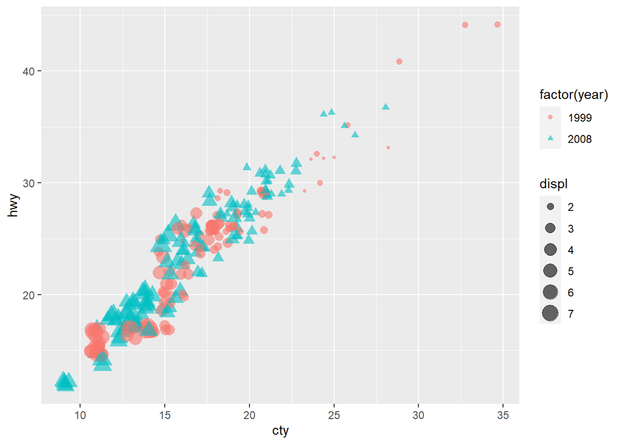

```r
library(ggplot2)
p <- ggplot(mpg, aes(cty, hwy))
p1 <- p + geom_point(aes(colour = factor(year),shape = factor(year), size = displ), alpha = 0.6, position = 'jitter')
print(p1)
```

我们将1999年生产车型用红色圆形表示，2008年用兰色三角形表示，排量用图形的大小表示，并且设置了透明度和jitter以避免样本点之间的重叠。可观察到2008年生产的大排量车型较多，从而油耗较高，单位油耗行驶距离较短。

- 坐标的控制

上图右上角数据点较为稀疏，这种情况下可用对数变换。为了演示ggplot2对图形坐标的控制，我们对X轴和Y轴均进行对数变换，然后对X轴的坐标显示加以限制，只显示X轴数据的均值，以及一倍标准差的坐标。

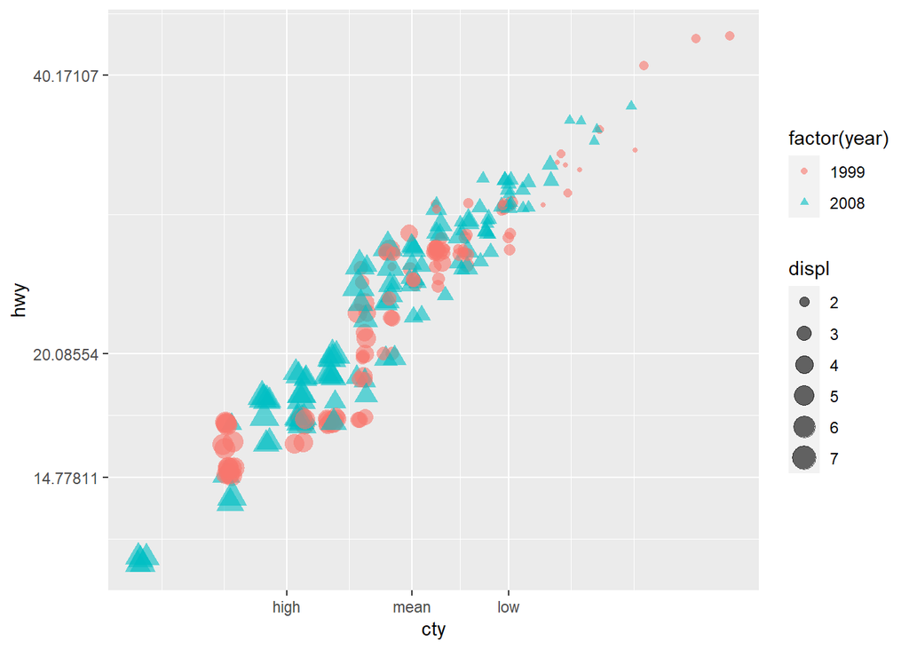

```r
cty.mean=with(mpg,mean(cty))
cty.sd=with(mpg,sd(cty))
p1 + scale_x_continuous(trans='log',breaks=c(cty.mean-cty.sd,cty.mean,cty.mean+cty.sd), labels=c("high", "mean", "low")) + scale_y_continuous(trans='log')
```

- 文字说明

利用geom_text函数可添加文字说明以增强图形的可读性

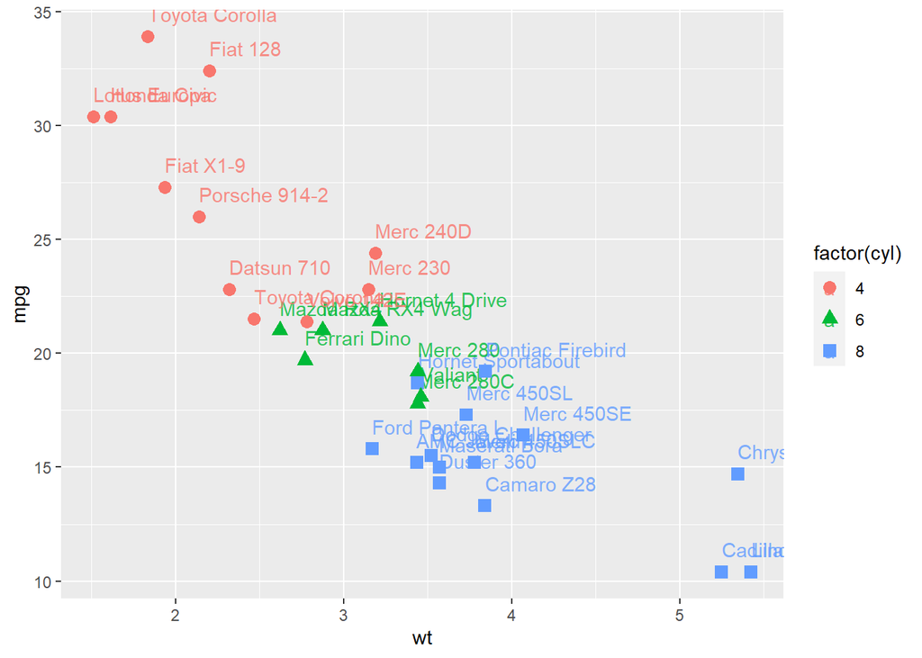

```r
p <- ggplot(mtcars, aes(x=wt, y=mpg,colour=factor(cyl),label=rownames(mtcars)))
p + geom_text(hjust=0,vjust=-1,alpha=0.8)+ geom_point(size=3,aes(shape=factor(cyl)))
```

### ggplot2绘制时间序列变化图

ggplot2包也能对时间序列数据绘图，但在处理上需要有些注意的地方，可能需要注意转化成data.frame。ggplot()可以先将时间序列类型拆成数据框类型然后再绘图。

#### <疫情时间序列变化>

可能涉及的方法：

- list.files遍历文件
- read_excel读取EXCEL文件
- for循环读取文件夹内所有EXCEL
- ymd时间提取
- rbind/cbind数据框行列的合并
- labs标注X轴、Y轴标题
- theme_bw使用空白模版可视化效果
- theme标题、坐标轴、图例等文字格式、文字大小、位置设置